# Reproducible Research: Peer Assessment 1

Phil Bagienski

## Loading and preprocessing the data

Download, unzip, and read the data file.

```r
download.file("https://d396qusza40orc.cloudfront.net/repdata%2Fdata%2Factivity.zip",
        "datafile.zip")
unzip("datafile.zip")
data <- read.csv("activity.csv")
```

Preprocessing: Turn dates into Date format

```r
data$date <- as.Date(data$date, "%Y-%m-%d")
```

## What is mean total number of steps taken per day?

Calculate total number of steps taken per day and display as histogram.

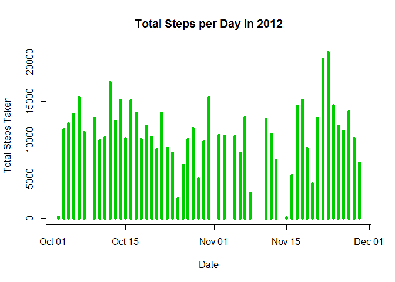

```r
dayTotals <- aggregate(steps~date, data=data, FUN=sum)
plot(steps~date, data=dayTotals, type="h", xlab="Date", ylab="Total Steps Taken",
       main="Total Steps per Day in 2012", lwd=5, col=3)
```

Calculate the mean and median number of steps per day.

```r
meanSteps=mean(dayTotals$steps)
medianSteps=median(dayTotals$steps)
```

## What is the average daily activity pattern?

Average the number of steps per each interval and display as a time series plot.

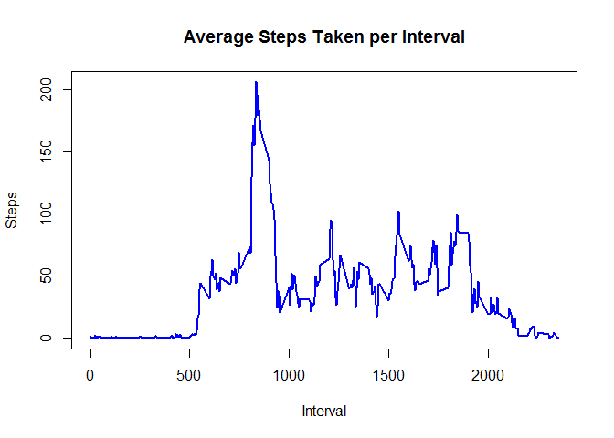

```r
intMeans <- aggregate(steps~interval, data=data, FUN=mean)
plot(steps~interval, data=intMeans, type="l", xlab="Interval", ylab="Steps",
    main="Average Steps Taken per Interval", lwd=2, col=4)
```

Find the 5-minute interval containing the maximum number of steps.

```r
max <- intMeans[which.max(intMeans$steps),1]
```

The interval containing the max number of steps is 835

## Imputing missing values

Calculate the total number of missing values in the dataset.

```r
missing <- sum(is.na(data$steps))
```

There are 2304 missing values in this dataset.

```r
fixedData <- data
naIndex <- which(is.na(fixedData$steps))
meansData <- mergedMeans<-merge(fixedData, intMeans, by="interval",
        suffixes=c(".actual", ".average"))
fixedData[naIndex,"steps"] <- meansData[naIndex,"steps.average"]
```

Using this “fixed” data, make a histogram of the total number of steps taken each day.

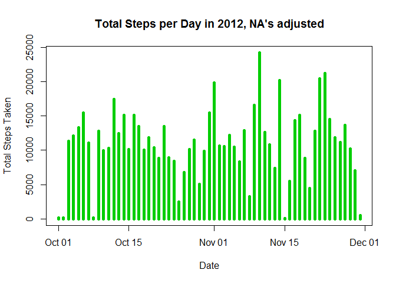

```r
newdayTotals <- aggregate(steps~date, data=fixedData, FUN=sum)
plot(steps~date, data=newdayTotals, type="h", xlab="Date", ylab="Total Steps Taken",
    main="Total Steps per Day in 2012, NA's adjusted", lwd=5, col=3)
```

Calculate the mean and median number of steps per day.

```r
newmeanSteps <- mean(newdayTotals$steps)
newmedianSteps <- median(newdayTotals$steps)
```

## Are there differences in activity patterns between weekdays and weekends?

Create a new factor variable in the dataset with two levels - “weekday” and “weekend” indicating whether a given date is a weekday or weekend day.

```r
weekdata <- fixedData
weekdata$day <- weekdays(weekdata$date)
for (i in 1:nrow(weekdata)) {
        if (weekdata$day[i] == "Saturday" | weekdata$day[i] == "Sunday") {
                weekdata$type[i] = "weekend"
        } else {
                weekdata$type[i] = "weekday"
    }
}
```

Make a panel plot containing a time series plot (i.e. type = “l”) of the 5-minute interval (x-axis) and the average number of steps taken, averaged across all weekday days or weekend days (y-axis).

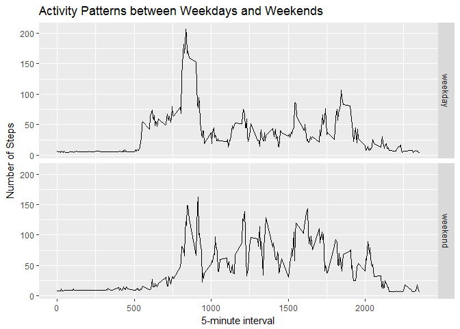

```r
library(ggplot2)
weekMeans <- aggregate(steps~interval*type, data=weekdata, FUN=mean)
weekMeans$type <- as.factor(weekMeans$type)
ggplot(weekMeans, aes(interval, steps)) + geom_line() + facet_grid(type~ .) +
         xlab("5-minute interval") + ylab("Number of Steps") + ggtitle("Activity Patterns between Weekdays and Weekends")
```